# Numerical and Statistical Methods for Approximating Financial Option Values

We will be exploring the explicit finite difference and Monte-Carlo methods to approximate solutions to the Black-Scholes model for pricing European call options. The goal of this post is to compare these approximations to the known solution to validate the usefulness of numerical methods in models where the exact solution is unknown.

[More info on the Black-Scholes Model](https://en.wikipedia.org/wiki/Black%E2%80%93Scholes_model)

The Black-Scholes PDE for the value $C(S, t)$ at time $t$ and underlying price $S$ of a European call option is

$$\frac{\partial C}{\partial t}(S,t) - \frac{1}{2} \sigma^2 S^2 \frac{\partial^2 C}{\partial S^2}(S,t) - rS\frac{\partial C}{\partial S}(S,t) + rC(S,t) = 0$$

with the intial condition of

$$C(S, 0) = \text{max}(S-E, 0)$$

and boundary conditions

$$C(0,t) = 0$$$$\frac{C(S, t)}{S} \rightarrow 1, \; \text{as } S \rightarrow \infty$$

## Finite Difference Method

After discretizing both the time and underlying price domains by length $dt$ and $dS$ respectively, we can use finite difference representations to approximate the partial derivatives across the time and price grid (denoted as $C(S,t) \approx c_S^t$). For the explicit method, we can use the following three approximations:

Forward difference for first-order time derivative:

$$\frac{\partial C}{\partial t}(n, m) = \frac{c_n^{m+1} - c_n^m}{dt}$$

Central difference for first-order price derivative:

$$\frac{\partial C}{\partial S}(n, m) = \frac{c_{n+1}^m - c_{n-1}^m}{2dS}$$

Central difference for second-order price derivative:

$$\frac{\partial^2 C}{\partial S^2}(n, m) = \frac{c_{n+1}^m - 2c_n^m + c_{n-1}^m}{dS^2}$$

We can use these approximations in the Black-Scholes PDE to formulate the approximation of $c_n^{m+1}$ by using the values of $c_{n-1}^m$, $c_{n}^m$, and $c_{n+1}^m$ after the algebra as

$$c_n^{m+1} = \frac{1}{2}(\sigma^2 n^2 dt - rndt)c_{n-1}^m + (1 - \sigma^2 n^2 dt - rdt)c_n^m + \frac{1}{2}(\sigma^2 n^2 dt + rn dt)c_{n+1}^m$$

Using the initial conditions, we can start at $t = 0$ and iterate through each time interval solving for each nodal approximation across the price domain.

[Visit "Numerical Approximations of Black-Scholes Equation" for more info](https://downloads.dxfeed.com/specifications/dxLibOptions/Mosneagu.pdf)

```python
import numpy as np
from scipy.stats import norm
import matplotlib.pyplot as plt
#from matplotlib import cm
import warnings
from scipy import sparse
```

```python
def FiniteDifferenceBlackScholes(E, sig, r, T_max, N, M):

    # Initialize grid
    S_max = 3 * E
    C = np.zeros((N + 1, M + 1))
    ds = S_max / N
    dt = T_max / M

    # For commonly used values
    alpha = dt * (sig ** 2)
    beta = dt * r

    # Initial condition: C(S, 0) = max(S - E, 0)
    C[:, 0] = np.maximum(np.arange(N + 1) * ds - E, np.zeros(N + 1))

    # Boundary condition: C(S_max, t) = S - E for all t
    C[-1, :] = np.ones(M + 1) * (S_max - E)

    # Construct matrix A
    d = 1 - alpha * (np.arange(1, N) ** 2) - beta
    u = 0.5 * (alpha * ((np.arange(2, N + 1) - 1) ** 2) + beta * (np.arange(2, N + 1) - 1))
    l = 0.5 * (alpha * ((np.arange(0, N - 1) + 1) ** 2) - beta * (np.arange(0, N - 1) + 1))

    A = np.diag(d)
    for i in range(N - 1):
        if i < N - 2:
            A[i, i + 1] = u[i]
        if i > 0:
            A[i, i - 1] = l[i]

    # Use a sparse matrix for quicker computations due to diag structure
    A = sparse.csr_matrix(A)

    # Iterate across each time step to solve option value at each S
    for j in range(M):
        C[1:-1, j + 1] = A.dot(C[1:-1, j])
        C[1, j + 1] = C[1, j + 1] + l[0] + C[0, j]
        C[-2, j + 1] = C[-2, j + 1] + u[-1] * C[-1, j]

    return C
```

Now we can supply the model with option parameters to solve.

```python
# Call option parameters
T_max = 0.2 # tenor/time
N = 1_000 # number of price intervals
M = 40_000 # number of time intervals
E = 20 # strike price
sig = 0.35 # vol
r = 0.05 # risk-free rate

# Discretize S and T domain
S = np.arange(N + 1) * (3 * E / N)
T = np.arange(M + 1) * (T_max / M)

# Approximate using Finite Difference
fd_approx = FiniteDifferenceBlackScholes(E, sig, r, T_max, N, M)
```

The results is a matrix that stores the value at each node. We can plot the value curve at current time and expiration.

For comparison, we define a function that formulates the analytical solution.

```python
def ExactBlackScholes(S, E, T, r, sig):

    with warnings.catch_warnings():
        warnings.simplefilter("ignore")
        d1 = (np.log(S / E) + (r + sig ** 2 / 2) * T) / (sig * np.sqrt(T))
        d2 = d1 - sig * np.sqrt(T)
        C = S * norm.cdf(d1) - E * np.exp(-r * T) * norm.cdf(d2)

    return C

exact = ExactBlackScholes(np.arange(3 * E), E, T_max, r, sig)
```

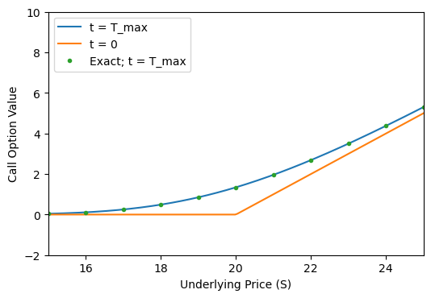

```python
fig, ax = plt.subplots()
plt.plot(S, fd_approx[:, -1], label = "t = T_max")
plt.plot(S, fd_approx[:, 0], label = "t = 0")
plt.plot(np.arange(3 * E), exact, ".", label = "Exact; t = T_max")
xlim = ax.set_xlim(right = 1.25 * E, left = 0.75 * E)
ylim = ax.set_ylim(top = 0.5 * E)
xlab = ax.set_xlabel("Underlying Price (S)")
ylab = ax.set_ylabel("Call Option Value")
leg = plt.legend(loc = "upper left")
fig.set_dpi(100)
p = plt.show()
```

To see how the value changes between these snapshots in time, we can add time to the plot to look at the surface plot.

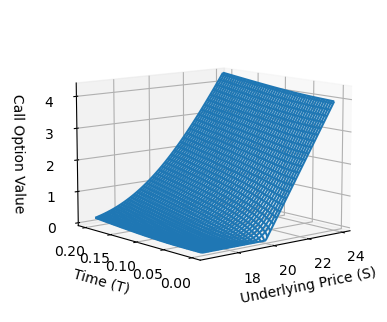

```python
fig, ax = plt.subplots(subplot_kw = {"projection": "3d"})
lb = 275
ub = 400
ax.plot_wireframe(np.tile(S, (M + 1, 1)).T[lb:ub, :], np.tile(T, (N + 1, 1))[lb:ub, :], fd_approx[lb:ub, :])
ax.azim += -70
ax.elev += -20
ax.set_xlabel("Underlying Price (S)")
ax.set_ylabel("Time (T)")
ax.set_zlabel("Call Option Value")
fig.set_dpi(100)
p3 = plt.show()
```

## Monte Carlo Method

The Monte Carlo method for approximating random systems is widely used across many use cases due to its generalized nature and ease of implementation. After making some assumptions about what random process underlying prices follow over time, we can start modeling right away. Unlike the finite difference method, we do not need to have any model/PDE to start pricing options and derive distributions from the results of our simulations.

The key assumption for the sake of this example will be that the underlying $S$ will follow Geometric Brownian Motion (GBM) process. This is consistent with the assumption of Black and Scholes. Namely, for our application this means that

$$S_t = S_{0} \text{exp}(-\frac{\sigma^2 t}{2} + \sigma W_t)$$

where $W_t$ follows Brownian Motion.

[Read more on GBM here](https://en.wikipedia.org/wiki/Geometric_Brownian_motion)

Thus, we can simulate thousands of Brownian Motion processes to derive the price of the underlying at expiration to derive the value of the option by averaging over all the payouts, namely

$$\frac{e^{-rt}}{N}\sum^N \text{max}(S_{t} - E, 0)$$

```python
def MonteCarloBlackScholes(E, sig, r, T_max, I, mu = 0):

    # Initialize values
    C = np.array([])
    S_max = 3 * E
    dt = T_max

    # Monte Carlo Simulation
    W = np.cumsum(np.random.standard_normal(size = (1, I, S_max)), axis = 0) * np.sqrt(dt)
    X = (mu - 0.5 * sig ** 2) * T_max + sig * W[-1, :, :]
    S = np.multiply(np.tile(np.arange(S_max), (I, 1)), np.exp(X))
    vals = np.maximum(S - E, np.zeros((I, S_max)))
    C = np.mean(vals, axis = 0) * np.exp(-r * T_max)

    return C
```

We can simulate and compare results from 100 iterations vs 10,000 iterations at each initial price point.

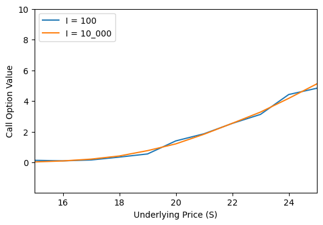

```python
mc_approx1 = MonteCarloBlackScholes(E, sig, r, T_max, 100)
mc_approx2 = MonteCarloBlackScholes(E, sig, r, T_max, 10_000)

fig, ax = plt.subplots()
plt.plot(np.arange(S.max()), mc_approx1, label = "I = 100")
plt.plot(np.arange(S.max()), mc_approx2, label = "I = 10_000")
xlim = ax.set_xlim(right = 1.25 * E, left = 0.75 * E)
ylim = ax.set_ylim(top = 0.5 * E)
xlab = ax.set_xlabel("Underlying Price (S)")
ylab = ax.set_ylabel("Call Option Value")
leg = plt.legend(loc = "upper left")
fig.set_dpi(100)
p = plt.show()
```

As expected, the values converge to the solution as the number of simulations increase.